# 02. Looking at the data

Course index · Previous: basics · Next: statistical analysis

# Day 1 — what can we see before running a test?

**Your name:** write here.

Use about **40 minutes**: 15 for neurite histograms, 10 for the MMSE histograms, 10 for boxplots and mean bars, and 5 for the violin demonstration and a caption. You will adapt commands and make your own figures. The extensions on saving figures and ggplot2 can wait until you finish the main route. We will practise scatterplots at the end of notebook 3 and on day 2.

## Setup and import

Each notebook imports its own data. It should work even if the previous notebook has not been run.

```r
neurites <- read.csv("data/neurites.csv")
small <- read.csv("data/mmse_small.csv")
small$Group <- factor(small$Group, levels = c("Control", "AD"))
control <- small$MMSE[small$Group == "Control"]
ad <- small$MMSE[small$Group == "AD"]
```

`factor()` tells R that `Group` is categorical. The `levels` argument sets the order in plots. It does not turn the categories into a numerical measurement.

## 1. Histograms

A histogram divides the measurement scale into intervals, or **bins**, and counts observations in each interval. Adjacent bars describe one numeric scale. This differs from a bar chart of separate categories.

### Start with the neurite measurements

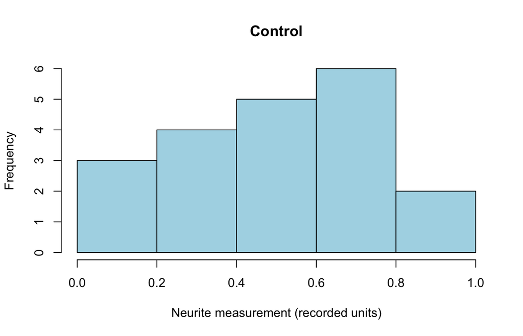

```r
hist(neurites$control, breaks = 5, col = "lightblue",
     main = "Control", xlab = "Neurite measurement (recorded units)")
```

`main` sets the title and `xlab` labels the horizontal axis. `breaks = 5` asks R for roughly five bins; R chooses convenient boundaries, so the actual number can differ. A vector of boundaries sets them explicitly. See the [R histogram reference](https://stat.ethz.ch/R-manual/R-devel/library/graphics/html/hist.html).

### Exercise — three conditions, several views

1. Copy the command into the empty chunk and adapt it to plot `condition_1` and `condition_2`. Change the titles as well as the selected columns.
2. Compare their centres, ranges, and shapes. Check the axis numbers: are all three panels using the same scale?
3. Plot `condition_2` with `breaks = 5`, then `breaks = 15`. Which features remain, and which depend on the bins? With twenty measurements, what happens when there are almost as many bins as observations?

**Two observations about the data, and one feature that depends on the plotting settings:**

### Make a fair comparison

Here are control and condition 1 using the same bins and axes. Compare this view with your individually scaled plots.

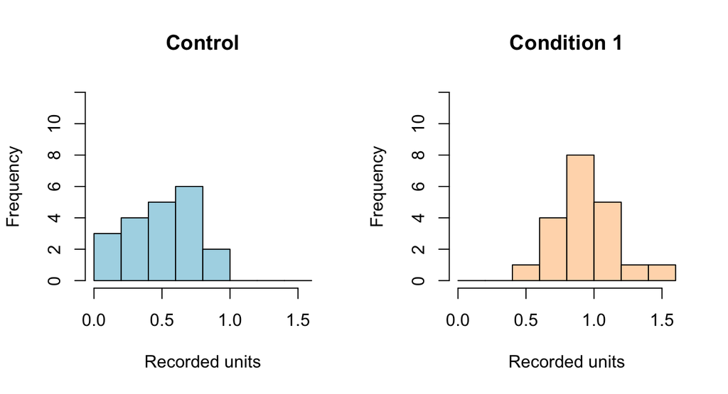

```r
neurite_breaks <- seq(0, 1.6, by = 0.2)
par(mfrow = c(1, 2))
hist(neurites$control, breaks = neurite_breaks, xlim = c(0, 1.6),
     ylim = c(0, 12), main = "Control", xlab = "Recorded units", col = "lightblue")
hist(neurites$condition_1, breaks = neurite_breaks, xlim = c(0, 1.6),
     ylim = c(0, 12), main = "Condition 1", xlab = "Recorded units", col = "peachpuff")
```

```r
par(mfrow = c(1, 1))
```

**Discuss:** Why would these boundaries fail for condition 2? How would putting all three conditions on a 0–12 axis change what you can see in control and condition 1? Shared scales help comparisons, but can hide detail in the narrower distributions.

### Now return to MMSE

The same plotting function works for scores. Their integer scale and upper limit call for different bin choices.

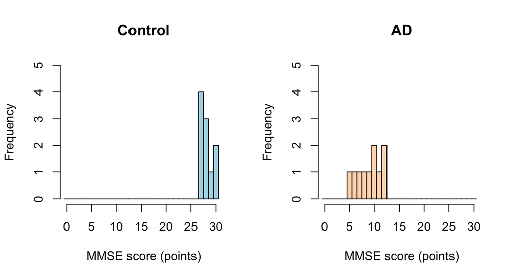

```r
par(mfrow = c(1, 2))
hist(control, breaks = seq(-0.5, 30.5, by = 1),
     xlim = c(0, 31), ylim = c(0, 5), col = "lightblue",
     main = "Control", xlab = "MMSE score (points)")
hist(ad, breaks = seq(-0.5, 30.5, by = 1),
     xlim = c(0, 31), ylim = c(0, 5), col = "peachpuff",
     main = "AD", xlab = "MMSE score (points)")
```

```r
par(mfrow = c(1, 1))
```

`par(mfrow = c(1, 2))` creates one row of two plots. The last line returns to one plot. `seq()` makes the sequence of bin boundaries; here, one bin per possible integer score. Both panels use the same axes and bins.

### Exercise 1

1. Describe the centre and spread of each group. Does either group approach the maximum possible score?
2. Copy the AD histogram command below and change its breaks to `seq(-0.5, 31.5, by = 4)`. How does the appearance change?
3. Did changing the bins change any observations? Can ten values tell you precisely what the population distribution looks like?

```r
# Copy the AD histogram command here and change the breaks.
```

**Your interpretation:**

## 2. Boxplots and individual observations

The line inside a box is the median. The box spans the lower and upper hinges, which are close to the first and third quartiles. For small datasets, these may differ slightly from the default `quantile()` calculation.

In R’s default boxplot, whiskers reach the most extreme observations within 1.5 IQR of the hinges. Values beyond the whiskers are plotted separately. These are observations to inspect, not observations to automatically delete.

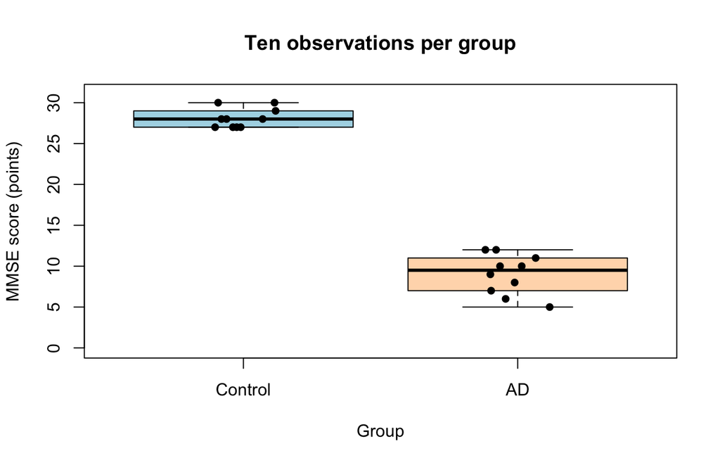

```r
boxplot(MMSE ~ Group, data = small,
        col = c("lightblue", "peachpuff"), ylim = c(0, 31),
        outline = FALSE, ylab = "MMSE score (points)",
        main = "Ten observations per group")
set.seed(7)
stripchart(MMSE ~ Group, data = small, vertical = TRUE,
           method = "jitter", jitter = 0.12, add = TRUE, pch = 16)
```

`MMSE ~ Group` reads as “MMSE by group”. `stripchart()` adds the observations. Jitter moves points slightly sideways so repeated scores are visible; it does not change their vertical values. `set.seed()` makes that sideways movement reproducible. `outline = FALSE` prevents extreme observations being drawn twice, because we add **all** points ourselves.

### Exercise 2

1. Find the median and the middle half of the observations in each group.
2. Why is it helpful to show the points when there are only ten observations per group?
3. Does the box represent a confidence interval for the mean?

**Your answers:**

### Exercise — show all three neurite conditions

Use `boxplot(neurites, outline = FALSE)` as your starting point. Add a title and label the vertical axis in recorded units. Then add the individual values using the supplied lines below in the same chunk.

```r
# Write your boxplot command first, then copy these lines below it:
# set.seed(7)
# stripchart(neurites, vertical = TRUE, method = "jitter", add = TRUE, pch = 16)
```

Remove the `#` from the two plotting lines when you use them. Compare your plot with the three histograms. Does the condition with the largest mean also have the narrowest spread? Can you see the overlap between control and condition 1 on this scale?

**Your interpretation:**

### Compare with a mean-only bar chart

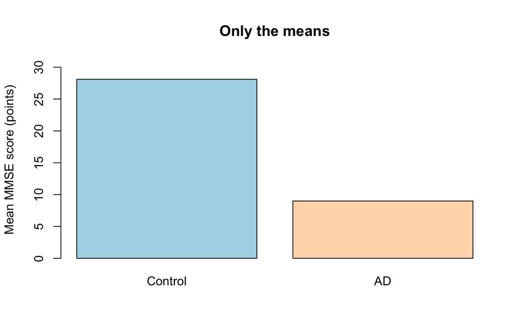

```r
barplot(c(mean(control), mean(ad)), names.arg = c("Control", "AD"),
        ylim = c(0, 31), col = c("lightblue", "peachpuff"),
        ylab = "Mean MMSE score (points)", main = "Only the means")
```

**Discuss:** What information did we lose? Would this chart tell us whether all AD observations were similar or whether a few very low scores pulled the mean down?

**Your answer:**

## 3. Violin plots — instructor demonstration

A violin is a smoothed estimate of a distribution, mirrored around its centre. Wider parts indicate higher estimated density. Width is not a confidence interval. These violins use equal maximum widths, so their widths do not compare group sample sizes.

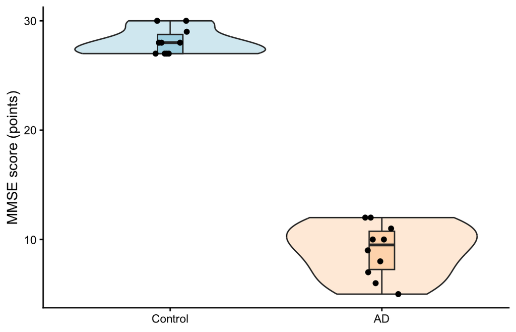

Violin plots with the original MMSE observations shown as points

The figure above is supplied. You do not need to run the following code. It is included if you want to see how the instructor made it; it requires `ggplot2`.

```r
library(ggplot2)
ggplot(small, aes(x = Group, y = MMSE, fill = Group)) +
  geom_violin(trim = TRUE, scale = "width", alpha = 0.5) +
  geom_boxplot(width = 0.12, outlier.shape = NA) +
  geom_point(position = position_jitter(width = 0.08, height = 0, seed = 7)) +
  scale_fill_manual(values = c("lightblue", "peachpuff")) +
  labs(x = NULL, y = "MMSE score (points)") +
  theme_classic() +
  theme(legend.position = "none")
```

**Discuss together:** The scores are integers, but the violin is smooth. Where does that smooth shape come from? Is a detailed-looking curve strong evidence about the distribution when there are only ten observations?

Here the violin is trimmed to each group’s observed range. Smoothing still suggests values between actual integer scores. Always look at the points as well. See the [ggplot2 violin documentation](https://ggplot2.tidyverse.org/reference/geom_violin.html) for the plotting settings.

**One sentence about what the violin adds, and one limitation:**

## Before we continue

Choose the figure you would use to describe this small dataset and explain why. Include a caption naming the measurements, groups, and sample sizes. Keep axis labels and units; colour changes can wait.

**Your choice and caption:**

## Extra: save a figure — 5 minutes

The HTML keeps your plots with your analysis. You may also need a separate figure for a presentation. Run this chunk to save a PDF inside the project’s `outputs/` folder.

```r
dir.create("outputs", showWarnings = FALSE)
pdf("outputs/neurite_boxplot.pdf", width = 7, height = 5)
boxplot(neurites, outline = FALSE, ylab = "Neurite measurement (recorded units)")
set.seed(7)
stripchart(neurites, vertical = TRUE, method = "jitter", add = TRUE, pch = 16)
dev.off()
```

`pdf()` opens the output file; `dev.off()` finishes it. Run all the lines, then open the PDF from the Files pane. Check that the labels are readable. To retain the result when you Knit, change `eval=FALSE` to `eval=TRUE` after trying it.

## Extra: wide tables, long tables, and ggplot2 — 15–20 minutes

The original neurite table stores groups in separate columns. `stack()` places their values in one column and the condition labels in another. No extra package is needed for this step.

```r
neurites_long <- stack(neurites)
names(neurites_long) <- c("measurement", "condition")
head(neurites_long)
```

```
##   measurement condition
## 1  0.06372999   control
## 2  0.10308265   control
## 3  0.99902660   control
## 4  0.60876101   control
## 5  0.63159041   control
## 6  0.39914599   control
```

```r
dim(neurites_long)
```

```
## [1] 60  2
```

```r
table(neurites_long$condition)
```

```
##
##     control condition_1 condition_2
##          20          20          20
```

**Explain:** Why does the table now have sixty rows? Did we collect more measurements? Select only the `condition_2` rows using the logical selection you practised in notebook 1.

If `ggplot2` is installed, try the following chunk. Change `eval=FALSE` to `eval=TRUE` to include it when you Knit. `aes()` maps columns to positions or colours; each `+` adds a layer. `facet_wrap()` gives each condition its own panel.

```r
library(ggplot2)
ggplot(neurites_long, aes(x = measurement)) +
  geom_histogram(binwidth = 0.5, boundary = 0, colour = "white", fill = "steelblue") +
  facet_wrap(~ condition) +
  labs(x = "Neurite measurement (recorded units)", y = "Count") +
  theme_classic()

ggplot(neurites_long, aes(x = condition, y = measurement)) +
  geom_boxplot(outlier.shape = NA) +
  geom_point(position = position_jitter(width = 0.12, height = 0, seed = 7)) +
  labs(x = "Condition", y = "Neurite measurement (recorded units)") +
  theme_classic()
```

Change `binwidth` to 0.2, then 1. Explain which view is useful for each condition. Fixed facet scales make comparison possible, but the much wider condition 2 compresses the other groups. See the [ggplot2 histogram reference](https://ggplot2.tidyverse.org/reference/geom_histogram.html).

**Your explanation:**

## Extra: plots you may use in other biology courses

| Question | Useful plot | Check before interpreting |
| --- | --- | --- |
| How variable are protein measurements in a small experiment? | Dot/strip plot | Show independent replicates, not just repeated measurements of one sample |
| How did the same cultures change after treatment? | Paired points connected by lines | Connect only measurements from the same experimental unit |
| How does a response change over time? | Time-course plot | Distinguish individual trajectories from a group average |
| How large are several estimated treatment effects? | Effect estimates with confidence intervals | Label the effect units and what the intervals represent |
| How does response change with concentration? | Dose–response plot | Inspect the concentration scale; curve fitting comes later |
| Which genes or proteins show similar patterns? | Heatmap | Read the colour key and check whether each row was scaled |

Continue to notebook 3: normality and statistical tests